# Czy lata nauki pomagają przewidzieć czas w sieci?

Wzór raportu do laboratorium 3

2026-11-23

## Pytanie

Czy z liczby lat nauki da się przewidzieć, ile minut dziennie nowa osoba spędza w internecie, i czy wiek coś do tego dodaje?

## Dane

Dane pochodzą z European Social Survey 2023 dla Polski. O czas w internecie pytano tylko osoby, które z niego korzystają. Z odpowiedzią o wieku, latach nauki i minutach zostało 1035 osób; średnio uczyły się 14 lat i spędzały w sieci 231 minut dziennie.

## Metoda

Osoby podzieliłam losowo: 828 do uczenia modeli i 207 do testu. Na osobach uczących policzyłam dwie proste regresje: z samymi latami nauki oraz z latami nauki i wiekiem. Każdy model sprawdziłam na osobach testowych, których nie widział. Pomyłkę mierzę jako RMSE w minutach, które mocniej karze duże pomyłki, i porównuję je z prognozą, która każdemu daje średnią.

## Wyniki

Typowa pomyłka prognozy minut w sieci u nowych osób.

| Model | Pomyłka na testowych (min) |
| --- | --- |
| Sama średnia | 185 |
| Lata nauki | 183 |
| Lata nauki i wiek | 173 |

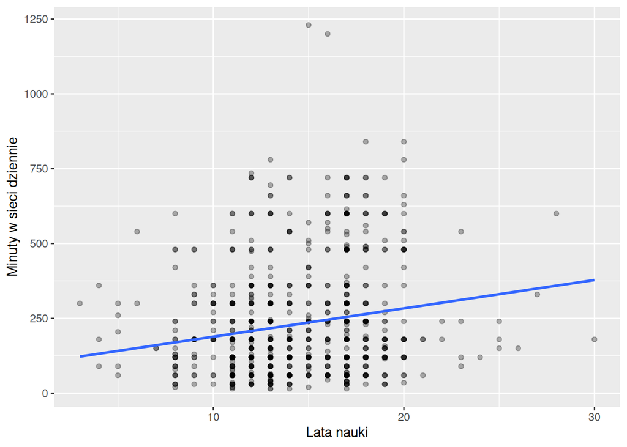

Lata nauki i minuty w sieci dziennie, osoby uczące. Linia to model z samymi latami nauki.

Linia rośnie: według modelu każdy rok nauki to około 9 minut w sieci więcej dziennie. Kropki leżą jednak daleko od niej, więc same lata nauki niewiele mówią o konkretnej osobie.

## Wnioski

Wybieram model z latami nauki i wiekiem, bo na nowych osobach myli się najmniej: o 173 min, wobec 183 dla samych lat nauki i 185 dla samej średniej. Same lata nauki pomagają więc niewiele, a razem z wiekiem pomyłka spada o 12 min; to wynik jednego losowego podziału, bez sprawdzianu krzyżowego. Model nie widzi pracy, studiów ani nawyków, więc konkretna osoba może odbiegać od prognozy o mniej więcej tyle, ile wynosi pomyłka.